# Data Science Society Christmas Workshop

Verity Tether

11th December 2019

## Introduction

It’s the most wonderful time of the year! It’s the Data Science Society Christmas Workshop!

This year’s Christmas workshop involves examining the frequency of words in both traditional Christmas Carols, and more modern Christmas songs.

In this workshop, you will:

- Install packages
- Scrape lyrics from a web page
- Clean text data
- Analyse the text data to identfy frequently-used words and word associations
- Visualise these results in bar charts and word clouds

## Introduction to R

This section will go into a little detail on R, for those of you who are complete beginners. If you are comfortable with R, open RStudio and go to the next section.

Firstly, open RStudio, the graphical user interface for R, and select File –> New File – RScript.

The RStudio window has four panes (they may be arranged differently on your screen):

[figure not shown]

- Console - where you can type commands (lines of code) and see output
- RScript - a text file containing basically the same lines of code as you would put in the console. You are able to add comments to the RScript which helps you understand your code as you go through it, and you can save it, so we 100% recommend you do your coding in the RScript
- Environment - shows all the R objects (eg data sets)
- Files/Plots/Packages/Help - *Files* shows the files/folders in your workspace, *Plots* shows your graphs, *Packages* lists the packages on the computer and *Help* can be used to get additional help.

When you download RStudio, there are a number of tools already installed in the software. However, we can also install *packages* - sets of additional tools which have been created by other R users. When we install them, we can call them as *libraries* and use these tools.

## Getting Started

The first thing we need to do is download a file called *songlyrics.html* from [my github](https://github.com/veritytether/ChristmasWorkshop) by pressing the *Clone or Download* button. Create a folder in your documents in which to save this.

We then need to set this folder as our working directory. There are several ways to do this, but my preferred method is to navigate to the folder your files are saved in. In the bar at the top, go to Session –> Set Working Directory –> Choose Directory and navigate to the folder you’ve saved the files in.

Next, we need to do to start this work is download the packages we need, and then call their libraries. So, run this code by copying and pasting it into the RScript. Then, highlight it all and press *Run*. This may take a moment, so please be patient. You will know it has finished when the console has a > symbol on the bottom line.

```r
install.packages("tidyverse")
install.packages("readtext")
install.packages("rvest")
install.packages("stringr")
install.packages("tm")
install.packages("wordcloud")
install.packages("tidytext")
install.packages("ggplot2")


library(tidyverse)
library(readtext)
library(rvest)
library(stringr)
library(tm)
library(wordcloud)
library(tidytext)
library(ggplot2)
```

## Importing the Data

### Scraping Christmas Carol Lyrics

We have found this [website](http://ldsguy.tripod.com/Christmas.carols.html) which has the lyrics of a number of carols. We will scrape the lyrics from this web page, clean them, and then analyse them.

Our first step is to retreive the data from the website, using the `read_html()` tool from the `rvest` package, as follows:

```r
url <- "http://ldsguy.tripod.com/Christmas.carols.html"
carolsURL <- read_html(url)
```

Next, we have to select the information from the page that we are interested in analysing. To do this, we first need to understand a little about the structure of the web page, and the HTML code behind it.

HTML describes the structure of a web page, and contains the information in distinct sections, represented by “tags”. To have a look at the structure of this web page, open it and right click anywhere on the page, and select *Inspect*. If there are only a few lines of code in your Elements pane, as in the scren shot below, click on the arrow next to *Body*, marked on the image.

[figure not shown]

Once you can see the additional information, scroll slowly down the webpage, with your cursor over the text in the *Elements* pane. As you can see, when your cursor is over the section of the webpage it refers to, it highlights it, as demonstrated below:

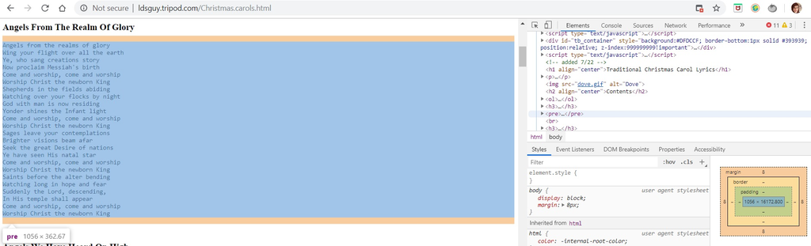

As the main text of each of the carols is listed by the tag *pre*, we will get R to select only the words which are in the *pre* tags on the website:

```r
carolsText <- carolsURL %>%
  html_nodes("pre") %>%
  html_text() # this converts it into text rather than in html code
```

### Importing Christmas Song Lyrics

This [website](https://www.liveabout.com/top-christmas-songs-3245323) identified the Top 100 Christmas Songs (even if we disagree with some of them!). We will use the top 25, as we have scraped the lyrics for 25 carols.

We have already put the lyrics of the top 25 into an HTML file for you, which is the file you downloaded at the start of the session. We will repeat the same method of importing as before. This time, however, the tags which surround each song are *p*, so:

```r
songsfile <- ("songlyrics.html")
songs <- read_html(songsfile)

songsText <- songs %>%
  html_nodes("p") %>%
  html_text()
```

**Now we have all our data imported, we are ready to clean it!**

## Cleaning the Data

Data cleaning is a vital part of data analysis, as it involves “removing or modifying data that is incorrect, incomplete, irrelevant, duplicated, or improperly formatted” ([reference](https://www.sisense.com/glossary/data-cleaning/)).

### Christmas Carols

A good example of a carol which needs cleaning is *Angels We Have Heard On High*. Run the following line of code and see if you can identify an issue with the text which is currently saved for it:

```r
carolsText[2]
```

```
## [1] "\nAngels we have heard on high\nSweetly singing over the plains\nAnd the mountains in reply,\nEchoing their joyous strains.\nGlo-ori-a\nIn excelsis de-o\nGlo-ori-a\nIn excelsis de-o\nShepherds, why this Jubilee?\nWhy your joyous strains prolong?\nWhat the gladsome tidings be\nWhich inspire y…
```

We can see two issues with this data:

- Some of the words contain dashes, such as Glo-ori-a, so would be difficult to analyse compared to mentiones of Gloria in other carols
- It contains code for the white spaces, *\n*, which indicates that following lyrics are on the next line.

So, we need to remove the dashes and white spaces. Luckily, there are tools designed to do this:

```r
carolsClean <- carolsText %>%
  str_replace_all(pattern = "\\-", replacement = "") %>% # remove the dashes
  str_replace_all(pattern = "\\s+", replacement = " ") # remove the white space and replace with a space
```

We can check this has worked by looking at the text data for the same carol again:

```r
carolsClean[2]
```

```
## [1] " Angels we have heard on high Sweetly singing over the plains And the mountains in reply, Echoing their joyous strains. Glooria In excelsis deo Glooria In excelsis deo Shepherds, why this Jubilee? Why your joyous strains prolong? What the gladsome tidings be Which inspire your heavenly song?…
```

However, we can see now that Glo-ori-a has become Glooria, which also can’t be compared with Gloria. So, we will replace Glooria:

```r
carolsClean <- carolsClean %>%
  str_replace_all(pattern = "Glooria", replacement = "Gloria")
```

And, to check it one more time:

```r
carolsClean[2]
```

```
## [1] " Angels we have heard on high Sweetly singing over the plains And the mountains in reply, Echoing their joyous strains. Gloria In excelsis deo Gloria In excelsis deo Shepherds, why this Jubilee? Why your joyous strains prolong? What the gladsome tidings be Which inspire your heavenly song? G…
```

That looks much better!

### Christmas Songs

We will use the same methods to clean the data for christmas songs. This time, we need to remove the white space, and will replace the word “xmas” with “christmas”, so that each song uses the same word.

```r
songsClean <- songsText %>%
  str_replace_all(pattern = "\\s+", replacement = " ") %>% # remove the white space
  str_replace_all(pattern = "xmas", replacement = "Christmas") # replace xmas with christmas
```

## Analysing the Data

Now that the data has been cleaned, it is time to analyse it!

### Finding Frequent Words

Our first step is to identify which words appear frequently in the text. To do this, we have to convert the data into different data formats. Firstly, a *corpus*, which acts as a database for text objects.

```r
carol_corpus <- VCorpus(VectorSource(carolsClean))
```

Once the data is in a corpus, we are able to transform and pre-process the data, so that it is better for analysis. Here, we will:

- Put all the lyrics into lower case (to ensure that, for example **A**ngels and **a**ngels are not counted separately)
- Remove any punctuation (as we are looking at the words themselves rather than the punctuation)
- Remmove the very common words (called stop words), such as *the*, *and*, and *a*. It is standard practice to remove these words in text analysis, so that we are left with just the meaningful words in the text.

```r
carol_corpus <- tm_map(carol_corpus, content_transformer(tolower)) # lower case
carol_corpus <- tm_map(carol_corpus, removePunctuation) # remove punctuation
carol_corpus <- tm_map(carol_corpus, removeWords, stopwords("english")) # remove stop words
```

If you are curious to see which words have been removed by the `stopwords()` function, run this code to examine the stop words:

```r
stopwords("english")
```

```
##   [1] "i"          "me"         "my"         "myself"     "we"
##   [6] "our"        "ours"       "ourselves"  "you"        "your"
##  [11] "yours"      "yourself"   "yourselves" "he"         "him"
##  [16] "his"        "himself"    "she"        "her"        "hers"
##  [21] "herself"    "it"         "its"        "itself"     "they"
##  [26] "them"       "their"      "theirs"     "themselves" "what"
##  [31] "which"      "who"        "whom"       "this"       "that"
##  [36] "these"      "those"      "am"         "is"         "are"
##  [41] "was"        "were"       "be"         "been"       "being"
##  [46] "have"       "has"        "had"        "having"     "do"
##  [51] "does"       "did"        "doing"      "would"      "should"
##  [56] "could"      "ought"      "i'm"        "you're"     "he's"
##  [61] "she's"      "it's"       "we're"      "they're"    "i've"
##  [66] "you've"     "we've"      "they've"    "i'd"        "you'd"
##  [71] "he'd"       "she'd"      "we'd"       "they'd"     "i'll"
```

[output cut: 20 more lines]

Now that we have pre-processed the data, we must represent the corpus in a different format - a *document term matrix* (DTM). Here, the documents in the corpus are listed as rows, and the frequencies of the words in each of these documents is in the columns. Using a DTM means that we are able to do more quantitative analysis.

```r
carolsDTM <- DocumentTermMatrix(carol_corpus)
```

If we have a look at this DTM, we can see a table with word frequencies for each carol:

```r
inspect(carolsDTM)
```

[output not shown]

We can also look through the carols for the occurrence of specific words. This line of code, for example, looks for the word *angels*:

```r
inspect(carolsDTM[,("angels")])
```

It is also possible to look for words which occur more than a certain number of times. This code finds words which have occurred more than 5 times, and creates a variable of them called `CarolsFreq`:

```r
carolsFreq <- findFreqTerms(carolsDTM, lowfreq=5)
carolsFreq
```

The `findFreqTerms()` function creates a character vector, with the words arranged alphabetically rather than numerically. Although this can be useful, for this workshop we would rather know which words occur more frequently. To change this, we can sum the frequency of each term using the `colSums()` function. In order to use this function, we first need to convert our DTM into a more traditional matrix, and then convert that matrix into a data frame. This will enable us to visualise the data:

```r
carolsFreqTerms <- colSums(as.matrix(carolsDTM)) #convert the DTM into a matrix
sort(carolsFreqTerms, decreasing = TRUE) # to look at the data, the most frequent word first

carolsFreqTermsDF <- data.frame(word=names(carolsFreqTerms), freq=carolsFreqTerms) # to turn the matrix into a data frame
arrange(carolsFreqTermsDF, desc(freq))
```

Now that we have run the code separately for the carols, here it is for the christmas songs:

```r
song_corpus <- VCorpus(VectorSource(songsClean))
song_corpus <- tm_map(song_corpus, content_transformer(tolower)) # lower case
song_corpus <- tm_map(song_corpus, removePunctuation) # remove punctuation
song_corpus <- tm_map(song_corpus, removeWords, stopwords("english")) # remove stop words
songDTM <- DocumentTermMatrix(song_corpus)
songFreq <- findFreqTerms(songDTM, lowfreq=5)
songFreqTerms <- colSums(as.matrix(songDTM)) #convert the DTM into a matrix
sort(songFreqTerms, decreasing = TRUE) # to look at the data, the most frequent word first
songFreqTermsDF <- data.frame(word=names(songFreqTerms), freq=songFreqTerms) # to turn the matrix into a data frame
arrange(songFreqTermsDF, desc(freq))
```

### Finding Word Associations

A common requirement of text analysis is to examine which words frequently appear together. The `findAssocs()` tool allows us to do this. It returns a value between 0 and 1; 0 if the words never appear together, and 1 if they always appear together. We set a `corlimit`, to set the minimum correlation we are interested in.

The following code investigates which words are correlated with the word “angels” in carols. Do any of these surprise you?

```r
findAssocs(carolsDTM, "angels", corlimit = 0.6)
```

```
## $angels
##    sing  brings  prince sinners   skies
##    0.93    0.63    0.63    0.63    0.63
```

How do you think you would look for words which are correlated (0.6+) with the word “jingle” in christmas songs? The answer is at the bottom if you’re struggling!

## Visualisation

We will use both bar charts and word clouds to visualise this data.

### Bar Charts

Although there are several tools to create bar charts in R, we will use `ggplot2`.

Firstly, let’s make a bar chart of the words which feature in Christmas carols.

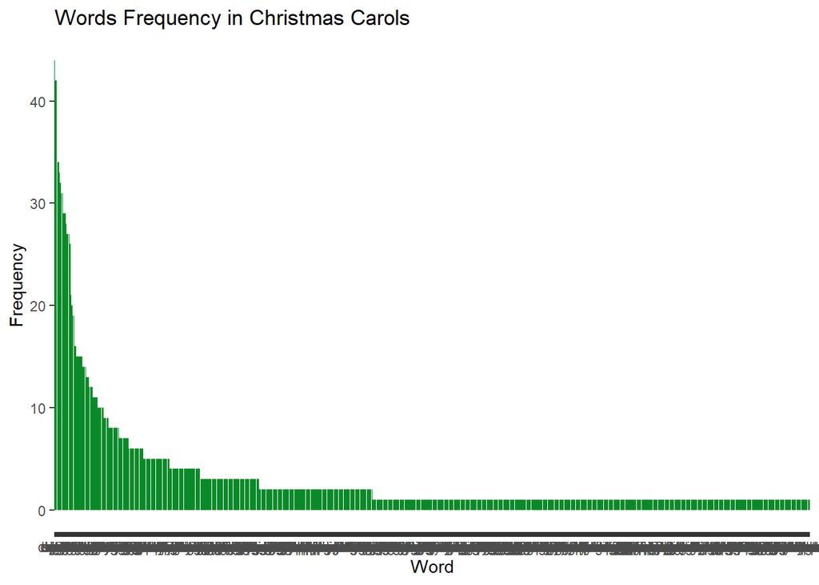

```r
ggplot(subset(carolsFreqTermsDF), aes(x = reorder(word, -freq), y = freq)) +
  geom_bar(stat = "identity", fill = '#088A29') +
  labs(title="Words Frequency in Christmas Carols",
       x ="Word", y = "Frequency")
```

However, there are several issues with this graph. Primarily, as there are *so many* words on this graph, we can’t see which word represents which frequency. Plus, are we really interested in the words which only feature a few times anyway?

To rectify this, we can create a bar chart whihch only includes words which feature a certain number of times. In this case, I selected 20 as the minimum:

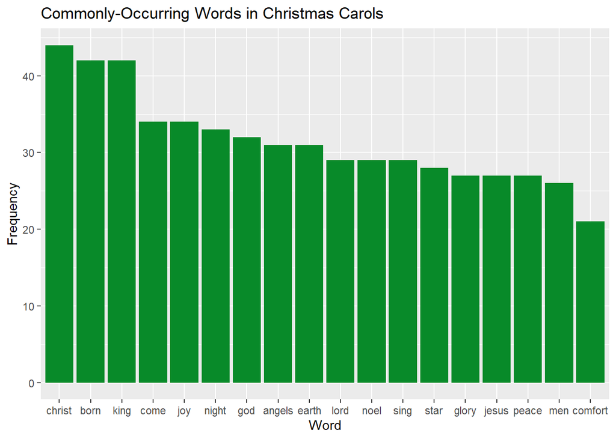

```r
ggplot(subset(carolsFreqTermsDF, freq>20), aes(x = reorder(word, -freq), y = freq)) +
  geom_bar(stat = "identity", fill = '#088A29') +
  labs(title="Commonly-Occurring Words in Christmas Carols",
        x ="Word", y = "Frequency")
```

We can do the same for Christmas songs:

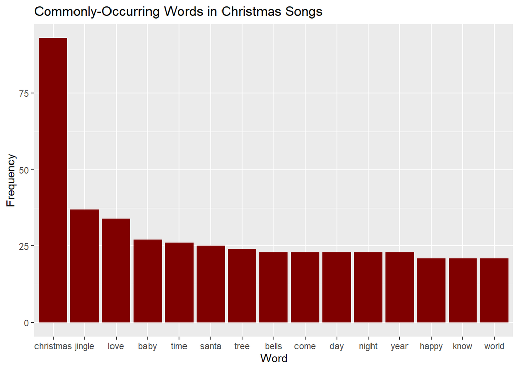

```r
ggplot(subset(songFreqTermsDF, freq>20), aes(x = reorder(word, -freq), y = freq)) +
  geom_bar(stat = "identity", fill = '#800000') +
  labs(title="Commonly-Occurring Words in Christmas Songs",
       x ="Word", y = "Frequency")
```

This graph shows that “christmas” occurs a lot more frequently than the other words; more than double the frequency of the next.

### Word Clouds

Whilst these bar charts are useful for identifying the most important words in the carols/songs, they don’t give us a good impression of the overall text. This is where wordclouds shine!

This code will create a wordcloud using all words which occurred in the carols:

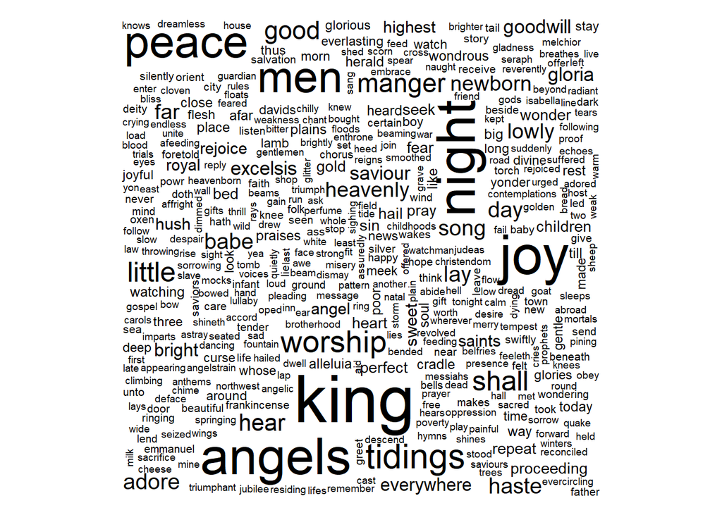

```r
wordcloud(carolsFreqTermsDF$word, carolsFreqTermsDF$freq, min.freq=1)
```

However, this isn’t very pretty, and some of the words are cut off. Moreover, as *all* the words are incuded, some are less important. So, let’s add a few more lines of code to improve it:

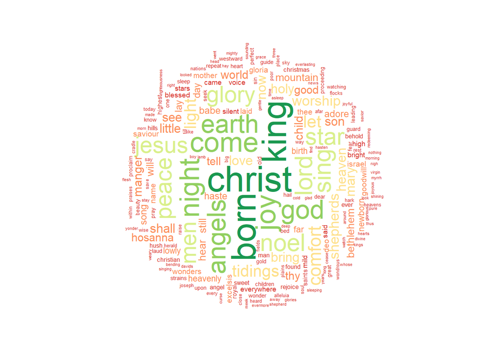

```r
wordcloud(carolsFreqTermsDF$word,
          carolsFreqTermsDF$freq,
          min.freq=3,# words which appeared more than 3 times
          max.words=Inf, # infinity number of max words
          random.order=FALSE, # the most common words will be in the middle
          rot.per=0.35, # words will be at 90 degree angles
          colors = brewer.pal(6, "RdYlGn"), # reds and greens as they're festive colours!
          scale=c(3,0.15)) # setting the height and width of the word cloud
```

We can do the same for the christmas songs:

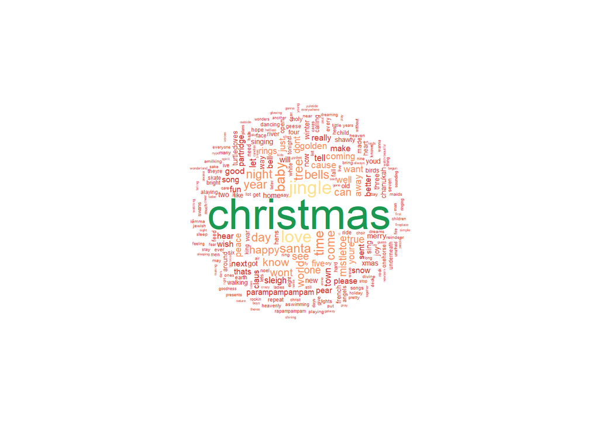

```r
wordcloud(songFreqTermsDF$word,
          songFreqTermsDF$freq,
          min.freq=3,# words which appeared more than 3 times
          max.words=Inf, # infinity number of max words
          random.order=FALSE, # the most common words will be in the middle
          rot.per=0.35, # words will be at 90 degree angles
          colors = brewer.pal(6, "RdYlGn"), # reds and greens as they're festive colours!
          scale=c(3,0.15)) # setting the height and width of the word cloud
```

As we saw in the bar chart, the word “christmas” occurs considerably more than the others. Although this was not a problem in the bar chart, as we were able to examine how much more frequently it occurred than others, it has skewed our word cloud and is hiding other patterns.

So, let’s remove the word christmas from the data and see how it looks without it!

Firstly, let’s create a duplicate of the songs data frame, so that we leave the original in tact:

```r
songsWithoutChristmas <- songFreqTermsDF
```

We then create a `subset()`, which takes this new data frame, and resets it as same data but without the word “christmas”.

```r
songsWithoutChristmas <- subset(songsWithoutChristmas, word!="christmas")
```

Now, we can make a new word cloud with this new dataframe:

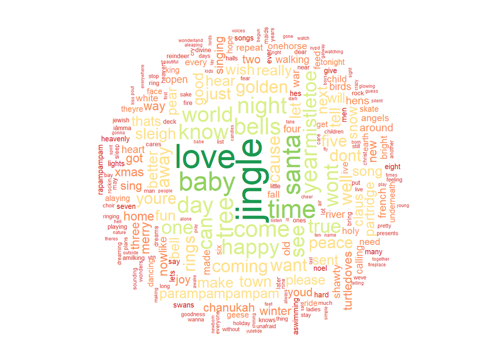

```r
wordcloud3 <- wordcloud(songsWithoutChristmas$word,
          songsWithoutChristmas$freq,
          min.freq=3,# words which appeared more than 3 times
          max.words=Inf, # infinity number of max words
          random.order=FALSE, # the most common words will be in the middle
          rot.per=0.35, # words will be at 90 degree angles
          colors = brewer.pal(6, "RdYlGn"), # reds and greens as they're festive colours!
          scale=c(3,0.15)) # setting the height and width of the word cloud
```

```r
wordcloud3
```

This looks a lot better - we are able to get more information from this word cloud now we have removed that word!

**Note** - if you’d like to export any of these images, you can save them as an image file by clicking this button and following the instructions.

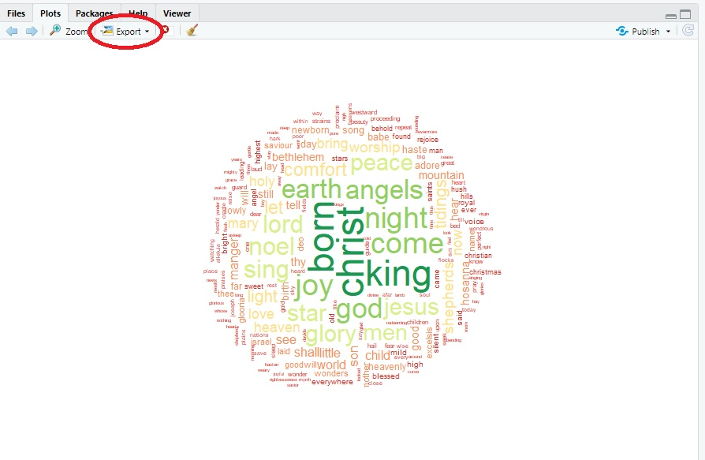

## Conclusions

As we have seen throughout this workshop, the words frequently occurring in the modern christmas songs are very different to those in traditional christmas carols.

Here are a few conclusions we can make from this analysis:

- When we examine the bar chart, we can see that only two words feature on both - *come* and *night*. These are the only words which are commonly used in both traditional carols and modern songs
- As expected, it seems that traditional carols are focused on religion and the Christian christmas story, whereas modern christmas songs are not
- None of the frequent words of christmas songs are notably religious

## Answers

To identify word association (0.6+) with the word “jingle” in christmas songs:

```r
findAssocs(songDTM, "jingle", corlimit = 0.6)
```